# Univariate Assignment

Caroline Oliver

1/30/2018

```r
treeData = read.csv(file = "http://dmcglinn.github.io/quant_methods/data/treedata_subset.csv", header = TRUE)

redMapleData = subset(treeData, species == "Acer rubrum")
frasierFirData = subset(treeData, species == "Abies fraseri")
```

## Data Plots

### Pairs Plot for Red Maple Data

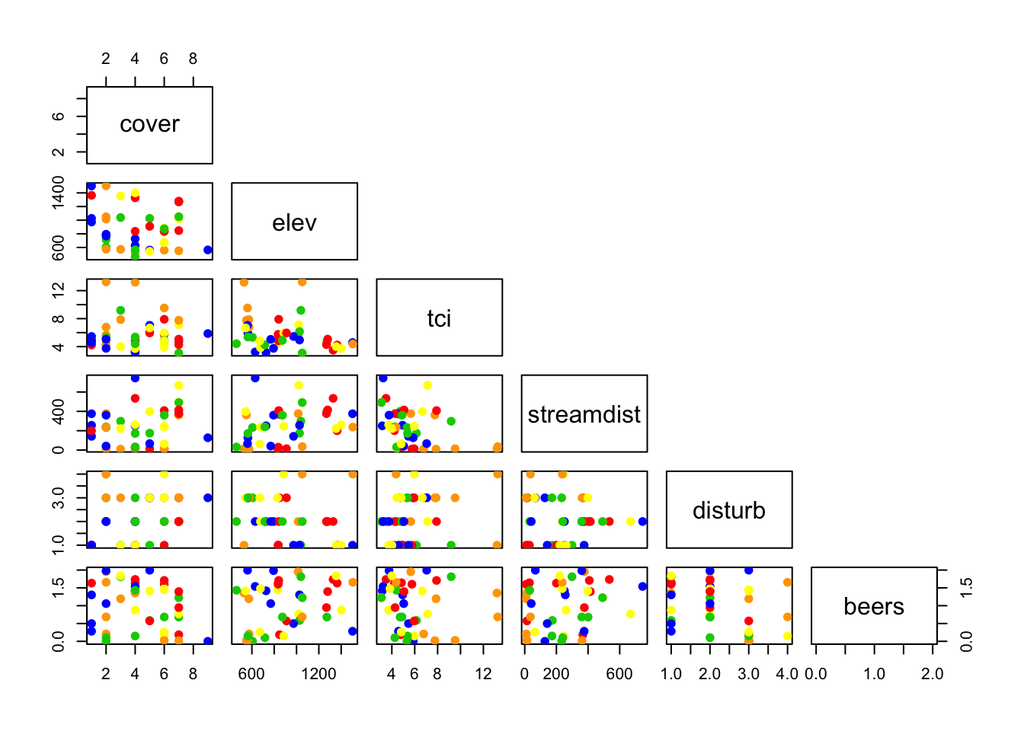

```r
redSample <- sample(1:723, 44, replace=F)
pairs(redMapleData[redSample,4:9], pch = 19, col = c("red", "green3", "blue", "yellow", "orange"), upper.panel = NULL)
```

### Pairs Plot for Fraiser Fir Data

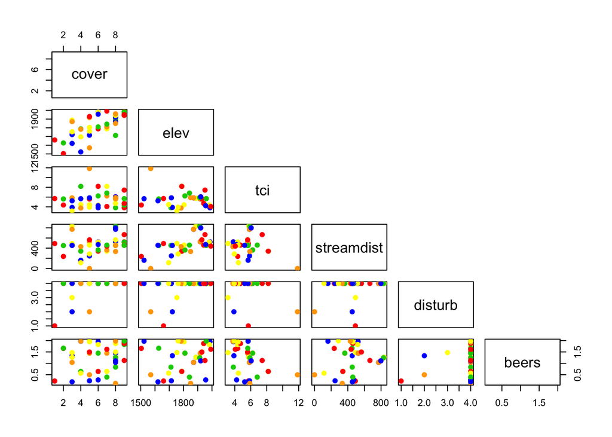

```r
pairs(frasierFirData[ ,4:9], pch = 19, col = c("red", "green3", "blue", "yellow", "orange"), upper.panel = NULL)
```

### OLS Summary for Red Maple Data

```r
redMapleOLS = lm(cover~elev + tci + streamdist + disturb + beers, data = redMapleData)
summary(redMapleOLS)
```

```
##
## Call:
## lm(formula = cover ~ elev + tci + streamdist + disturb + beers,
##     data = redMapleData)
##
## Residuals:
##     Min      1Q  Median      3Q     Max
## -4.7073 -1.2446  0.3409  1.3575  5.2732
##
## Coefficients:
##                 Estimate Std. Error t value Pr(>|t|)
## (Intercept)    6.3502303  0.4564973  13.911  < 2e-16 ***
## elev          -0.0010108  0.0003161  -3.197  0.00145 **
## tci           -0.0627613  0.0351922  -1.783  0.07495 .
## streamdist     0.0012895  0.0004756   2.712  0.00686 **
## disturbLT-SEL  0.0829610  0.2166747   0.383  0.70192
## disturbSETTLE -0.1044556  0.2804213  -0.372  0.70963
## disturbVIRGIN  0.3088364  0.2518161   1.226  0.22044
## beers         -0.3269597  0.1089662  -3.001  0.00279 **
## ---
## Signif. codes:  0 '***' 0.001 '**' 0.01 '*' 0.05 '.' 0.1 ' ' 1
##
## Residual standard error: 1.989 on 715 degrees of freedom
## Multiple R-squared:  0.04493,    Adjusted R-squared:  0.03558
## F-statistic: 4.805 on 7 and 715 DF,  p-value: 2.669e-05
```

### OLS Summary for Fraiser Fir Data

```r
frasierFirOLS = lm(cover~elev + tci + streamdist + disturb + beers, data = frasierFirData)
summary(frasierFirOLS)
```

```
##
## Call:
## lm(formula = cover ~ elev + tci + streamdist + disturb + beers,
##     data = frasierFirData)
##
## Residuals:
##     Min      1Q  Median      3Q     Max
## -3.4630 -0.6472  0.0788  1.0872  3.8017
##
## Coefficients:
##                 Estimate Std. Error t value Pr(>|t|)
## (Intercept)   -20.561173   4.271449  -4.814 2.65e-05 ***
## elev            0.012370   0.002523   4.903 2.02e-05 ***
## tci             0.287641   0.193467   1.487   0.1458
## streamdist     -0.001266   0.001585  -0.799   0.4296
## disturbLT-SEL   2.188367   2.097905   1.043   0.3038
## disturbSETTLE   1.527604   2.341471   0.652   0.5183
## disturbVIRGIN   3.025596   1.735921   1.743   0.0899 .
## beers           0.037551   0.500269   0.075   0.9406
## ---
## Signif. codes:  0 '***' 0.001 '**' 0.01 '*' 0.05 '.' 0.1 ' ' 1
##
## Residual standard error: 1.601 on 36 degrees of freedom
## Multiple R-squared:  0.5824, Adjusted R-squared:  0.5011
## F-statistic: 7.171 on 7 and 36 DF,  p-value: 2.215e-05
```

### Red Maple Anova

```r
anova(redMapleOLS)
```

```
## Analysis of Variance Table
##
## Response: cover
##             Df  Sum Sq Mean Sq F value   Pr(>F)
## elev         1   31.60  31.605  7.9900 0.004835 **
## tci          1   23.33  23.327  5.8972 0.015410 *
## streamdist   1   33.15  33.147  8.3800 0.003909 **
## disturb      3    9.35   3.117  0.7879 0.500831
## beers        1   35.61  35.613  9.0034 0.002789 **
## Residuals  715 2828.21   3.956
## ---
## Signif. codes:  0 '***' 0.001 '**' 0.01 '*' 0.05 '.' 0.1 ' ' 1
```

### Frasier Fir Anova

```r
anova(frasierFirOLS)
```

```
## Analysis of Variance Table
##
## Response: cover
##            Df  Sum Sq Mean Sq F value  Pr(>F)
## elev        1 105.749 105.749 41.2502 1.9e-07 ***
## tci         1   9.239   9.239  3.6038 0.06569 .
## streamdist  1   3.007   3.007  1.1729 0.28601
## disturb     3  10.679   3.560  1.3886 0.26196
## beers       1   0.014   0.014  0.0056 0.94058
## Residuals  36  92.289   2.564
## ---
## Signif. codes:  0 '***' 0.001 '**' 0.01 '*' 0.05 '.' 0.1 ' ' 1
```

## Linear Model Plots

### Red Maple Plots

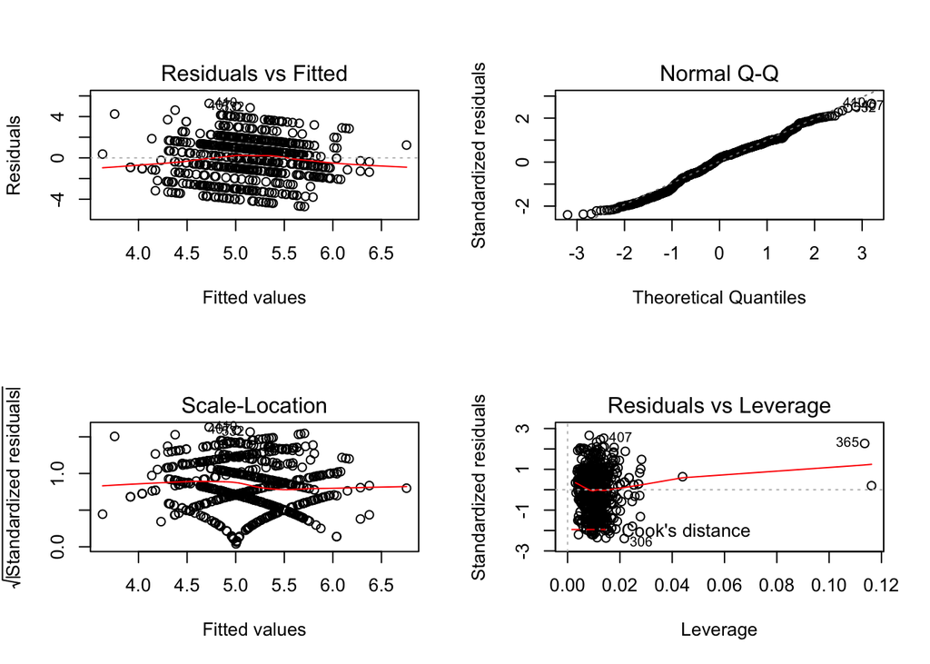

```r
par(mfrow=c(2,2))
plot(redMapleOLS)
```

### Frasier Fir Plots

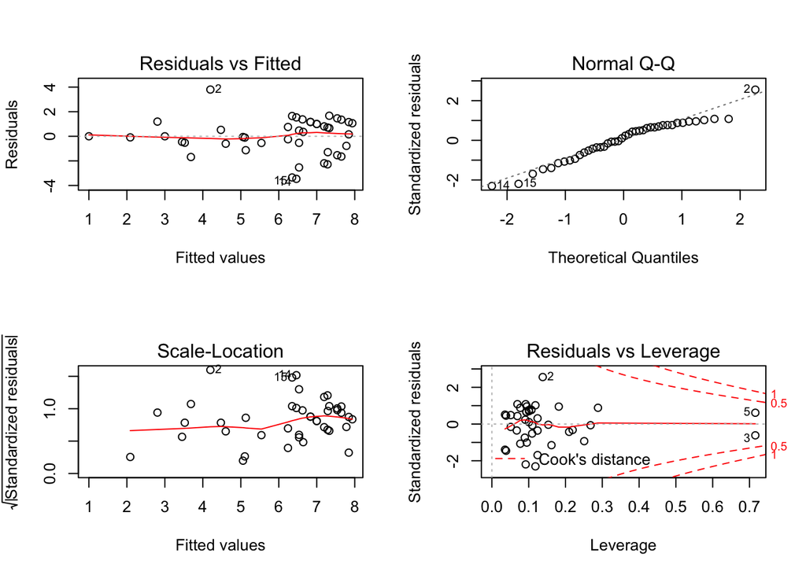

```r
par(mfrow=c(2,2))
plot(frasierFirOLS)
```

## Questions Set 1

### Which explanatory variables are the most important?

#### For the Red Maple Tree Data, the elevation stream distribution, and beers varaibles appear to be most important according to the anova performed on the Red Maple OLS model. All three variables had a significance code of 0.01. For the Frasier Fir Tree Data, elevation seems to be a very important varaible with a significance code of 0. The tci variable comes in as second most important with a significance code of 0.1 which is not typically seen as statisically significant.

### Do model diagnostics indicate any problems with violations of OLS assumptions?

#### For both the Red Maple Tree Model and the Frasier Fir Tree Model, the linear model plots seem to conclude that the data does not violate the OLS assumptions of linearity which can be seen in the residuals vs fitted plot in the upper left hand corner, or mulitvariate normality which can be seen in the Normal Q-Q plot in the upper right hand corner. There is also little multicolinearity which can be seen in the original pairs plots for both the Red Maple and the Frasier Fir Datasets.

### Are you able to explain variance in one species better than another, why might this be the case?

#### For variance we look at the adjusted R squared variable which for the Red Maple Data OLS is 0.03558 and for the Frasier Fir Data is 0.5011. This vast difference in adjusted R squared values can possibly be explained by the difference in sample size between the two datasets. The Red Maple Dataset has 723 values in it, while the Frasier Fir Dataset only has 44 values.